# Analiza danych wypłat w sektorze cybersecurity

### Źródło danych

Dane pochodzą ze zbiuru dostępnego na stronie Kaggle pod adresem: https://www.kaggle.com/datasets/deepcontractor/cyber-security-salaries

### Kolumny

- **work_year** - rok,z którego pochodzi wypłata
- **experience_level** - poziom doświadczenia
- **employment_type** - rodzaj zatrudnienia
- **job_title** - nazwa stanowiska pracy
- **salary** - wypłata we oryginalnej walucie
- **salary_currency** - waluta wypłaty w kodzie ISO 4217
- **salary_in_usd** - wypłata w usd
- **employee_residence** - obywatelstwo pracownika
- **remote_ratio** - praca zdalna, hybrydowa, na miejscu
- **company_location** - kraj siedziby firmy
- **company_size** - rozmiar firmy

### Import pakietów oraz bibliotek

Pakiet `tidyverse` to zestaw pakietów do kompleksowego przetwarzania i wizualizacji danych. W związku z tym załadowuje pakiet.

```r
library(tidyverse)
```

### Wczytanie danych

```r
cybersecurity <- read_csv("salaries_cyber.csv")
```

### Prezentacja zaczytanych danych

Przedstawienie podstawowych statystyk załadowanego zbioru danych oraz zapoznanie się z przykładowymi wartościami i ich typami.

```r
summary(cybersecurity)
```

```
##    work_year    experience_level   employment_type     job_title
##  Min.   :2020   Length:1247        Length:1247        Length:1247
##  1st Qu.:2021   Class :character   Class :character   Class :character
##  Median :2021   Mode  :character   Mode  :character   Mode  :character
##  Mean   :2021
##  3rd Qu.:2022
##  Max.   :2022
##      salary          salary_currency    salary_in_usd    employee_residence
##  Min.   :     1740   Length:1247        Min.   :  2000   Length:1247
##  1st Qu.:    79754   Class :character   1st Qu.: 74595   Class :character
##  Median :   120000   Mode  :character   Median :110000   Mode  :character
##  Mean   :   560852                      Mean   :120278
##  3rd Qu.:   160080                      3rd Qu.:150000
##  Max.   :500000000                      Max.   :910991
##   remote_ratio    company_location   company_size
##  Min.   :  0.00   Length:1247        Length:1247
##  1st Qu.: 50.00   Class :character   Class :character
##  Median :100.00   Mode  :character   Mode  :character
##  Mean   : 71.49
##  3rd Qu.:100.00
##  Max.   :100.00
```

```r
head(cybersecurity)
```

```
## # A tibble: 6 × 11
##   work_…¹ exper…² emplo…³ job_t…⁴ salary salar…⁵ salar…⁶ emplo…⁷ remot…⁸ compa…⁹
##     <dbl> <chr>   <chr>   <chr>    <dbl> <chr>     <dbl> <chr>     <dbl> <chr>
## 1    2022 EN      FT      Cyber …  63000 USD       63000 US           50 US
## 2    2022 MI      FT      Securi…  95000 USD       95000 US            0 US
## 3    2022 MI      FT      Securi…  70000 USD       70000 US            0 US
## 4    2022 MI      FT      IT Sec… 250000 BRL       48853 BR           50 BR
## 5    2022 EN      CT      Cyber … 120000 USD      120000 BW          100 BW
## 6    2022 EX      FT      Applic… 315000 USD      315000 US          100 US
## # … with 1 more variable: company_size <chr>, and abbreviated variable names
## #   ¹work_year, ²experience_level, ³employment_type, ⁴job_title,
## #   ⁵salary_currency, ⁶salary_in_usd, ⁷employee_residence, ⁸remote_ratio,
## #   ⁹company_location
```

```r
glimpse(cybersecurity)
```

```
## Rows: 1,247
## Columns: 11
## $ work_year          <dbl> 2022, 2022, 2022, 2022, 2022, 2022, 2022, 2022, 202…
## $ experience_level   <chr> "EN", "MI", "MI", "MI", "EN", "EX", "SE", "SE", "MI…
## $ employment_type    <chr> "FT", "FT", "FT", "FT", "CT", "FT", "FT", "FT", "FT…
## $ job_title          <chr> "Cyber Program Manager", "Security Analyst", "Secur…
## $ salary             <dbl> 63000, 95000, 70000, 250000, 120000, 315000, 220000…
## $ salary_currency    <chr> "USD", "USD", "USD", "BRL", "USD", "USD", "USD", "U…
## $ salary_in_usd      <dbl> 63000, 95000, 70000, 48853, 120000, 315000, 220000,…
## $ employee_residence <chr> "US", "US", "US", "BR", "BW", "US", "US", "US", "GB…
## $ remote_ratio       <dbl> 50, 0, 0, 50, 100, 100, 100, 100, 50, 100, 0, 100, …
## $ company_location   <chr> "US", "US", "US", "BR", "BW", "US", "US", "US", "GB…
## $ company_size       <chr> "S", "M", "M", "L", "S", "L", "M", "M", "L", "L", "…
```

Przedstawienie unikatowych wartości we wybranej kolumnie oraz liczby nie powtarzających się rekordów.

```r
cybersecurity %>%
  distinct(company_location)
```

```
## # A tibble: 55 × 1
##    company_location
##    <chr>
##  1 US
##  2 BR
##  3 BW
##  4 GB
##  5 SG
##  6 NL
##  7 IN
##  8 DE
##  9 AE
## 10 CA
## # … with 45 more rows
```

```r
cybersecurity %>%
  summarise(n = n_distinct(job_title))
```

```
## # A tibble: 1 × 1
##       n
##   <int>
## 1    87
```

### Weryfikacja wartości pustych

W zbiorze danych nie występują wartości puste.

```r
sum(is.na(cybersecurity))
```

```
## [1] 0
```

### Usunięcie zbędnych kolumn

W zbiorze występują 3 kolumny odnoszące się do wypłaty. W celu zapewnienia uniwersalności danych pozostawiono tylko kolumne z wypłata podaną we walucie usd.

```r
cybersecurity <- cybersecurity %>%
                  subset() %>%
                  select(-c("salary","salary_currency"))
head(cybersecurity)
```

```
## # A tibble: 6 × 9
##   work_year experience…¹ emplo…² job_t…³ salar…⁴ emplo…⁵ remot…⁶ compa…⁷ compa…⁸
##       <dbl> <chr>        <chr>   <chr>     <dbl> <chr>     <dbl> <chr>   <chr>
## 1      2022 EN           FT      Cyber …   63000 US           50 US      S
## 2      2022 MI           FT      Securi…   95000 US            0 US      M
## 3      2022 MI           FT      Securi…   70000 US            0 US      M
## 4      2022 MI           FT      IT Sec…   48853 BR           50 BR      L
## 5      2022 EN           CT      Cyber …  120000 BW          100 BW      S
## 6      2022 EX           FT      Applic…  315000 US          100 US      L
## # … with abbreviated variable names ¹experience_level, ²employment_type,
## #   ³job_title, ⁴salary_in_usd, ⁵employee_residence, ⁶remote_ratio,
## #   ⁷company_location, ⁸company_size
```

### Operacje na danych

#### Filtrowanie po nazwie stanowiska oraz lokalizacji siedziby firmy informacji na temat wypłaty w usd i obywatelstwa pracownika.

```r
cybersecurity %>%
  filter(job_title=="Security Analyst" & company_location=="CA") %>%
  select(job_title, salary_in_usd, company_location, employee_residence)
```

```
## # A tibble: 1 × 4
##   job_title        salary_in_usd company_location employee_residence
##   <chr>                    <dbl> <chr>            <chr>
## 1 Security Analyst         49424 CA               CA
```

#### Przedstawienie 10 największych stawek pracowników.

```r
cybersecurity %>%
  arrange(desc(salary_in_usd))%>%
  select(-c("employee_residence":"company_size"))%>%
  head(10)
```

```
## # A tibble: 10 × 5
##    work_year experience_level employment_type job_title                  salar…¹
##        <dbl> <chr>            <chr>           <chr>                        <dbl>
##  1      2022 SE               FT              Detection Engineer          910991
##  2      2022 SE               FT              Incident Response Manager   600000
##  3      2020 EX               FT              Security Engineering Mana…  600000
##  4      2022 SE               FT              Security Researcher         500000
##  5      2020 MI               FT              Ethical Hacker              456621
##  6      2021 SE               FT              Staff Security Engineer     450000
##  7      2022 MI               FT              Cyber Security Engineer     410000
##  8      2021 EX               FT              Chief Information Securit…  400000
##  9      2021 EX               FT              Chief Information Securit…  375000
## 10      2022 EX               FT              Information Security Comp…  360000
## # … with abbreviated variable name ¹salary_in_usd
```

#### Przedstawienie liczebności oraz podstawowych statystyk dla podgrup kolumny odpowiadającej za poziom doświadczenia. Wynik posortowany po średniej wypłaty rosnąco.

```r
salary_to_experience = cybersecurity %>%
    group_by(experience_level) %>%
    summarise(liczebnosc=n(),
            wyplata_srednia=mean(salary_in_usd),
            wyplata_mediana=median(salary_in_usd)) %>%
    arrange(wyplata_srednia)


print(salary_to_experience)
```

```
## # A tibble: 4 × 4
##   experience_level liczebnosc wyplata_srednia wyplata_mediana
##   <chr>                 <int>           <dbl>           <dbl>
## 1 EN                      215          63579.           63000
## 2 MI                      412         103377.           99925
## 3 SE                      547         144560.          135600
## 4 EX                       73         200706.          195316
```

[output not shown]

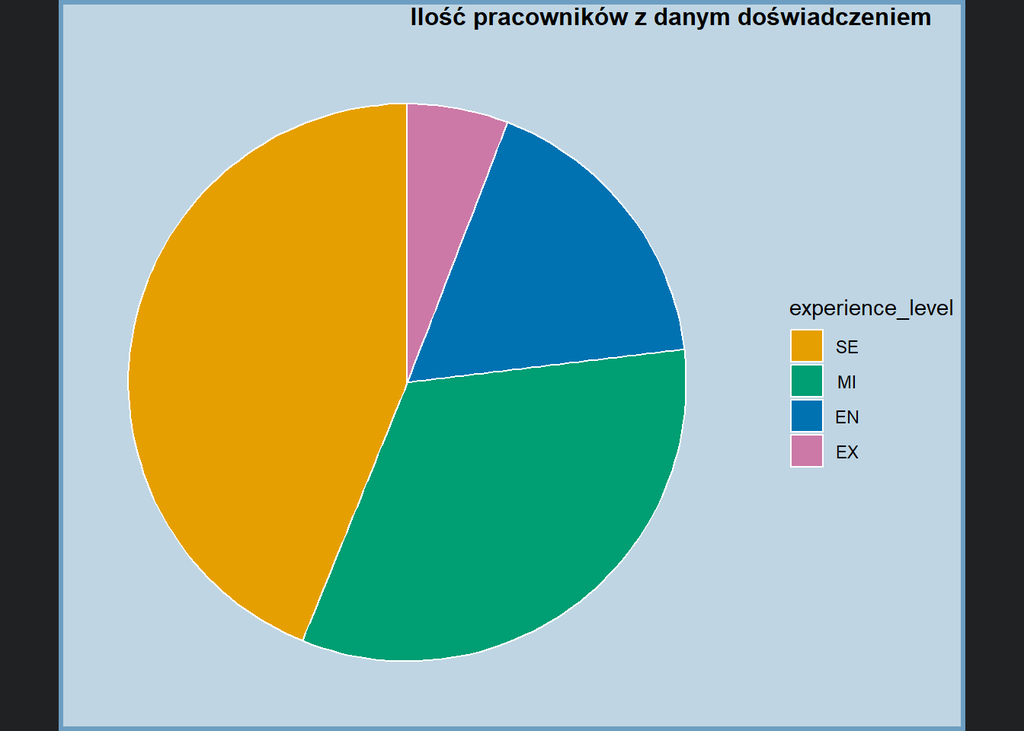

```r
salary_to_experience %>%
mutate(experience_level = fct_reorder(experience_level, desc(liczebnosc))) %>%
  ggplot(aes(x="", y=liczebnosc, fill=experience_level))+
  geom_bar(stat="identity", width=1, color="white") +
  coord_polar("y", start=0) +
  theme_void() +
  theme(plot.background =
          element_rect(fill = "#BFD5E3",
                       colour = "#6D9EC1",
                       linewidth = 2,
                       linetype = "solid"),
        plot.title = element_text(
                   size = 12,
                   face = 'bold',
                   hjust = 2,
                   vjust = 2),)+
  labs(title = "Ilość pracowników z danym doświadczeniem")
```

#### Przedstawienie 10 najpopularniejszych stanowisk pracy.

```r
most_popular_titles = cybersecurity %>%
  group_by(job_title) %>%
  summarise(amount=n()) %>%
  arrange(desc(amount)) %>%
  head(10)

print(most_popular_titles)
```

```
## # A tibble: 10 × 2
##    job_title                         amount
##    <chr>                              <int>
##  1 Security Engineer                    194
##  2 Cyber Security Analyst               133
##  3 Penetration Tester                    70
##  4 Information Security Manager          64
##  5 Cyber Security Engineer               63
##  6 Security Analyst                      47
##  7 Information Security Analyst          39
##  8 Cyber Security Specialist             31
##  9 Cyber Threat Intelligence Analyst     29
## 10 Information Security Officer          28
```

[output not shown]

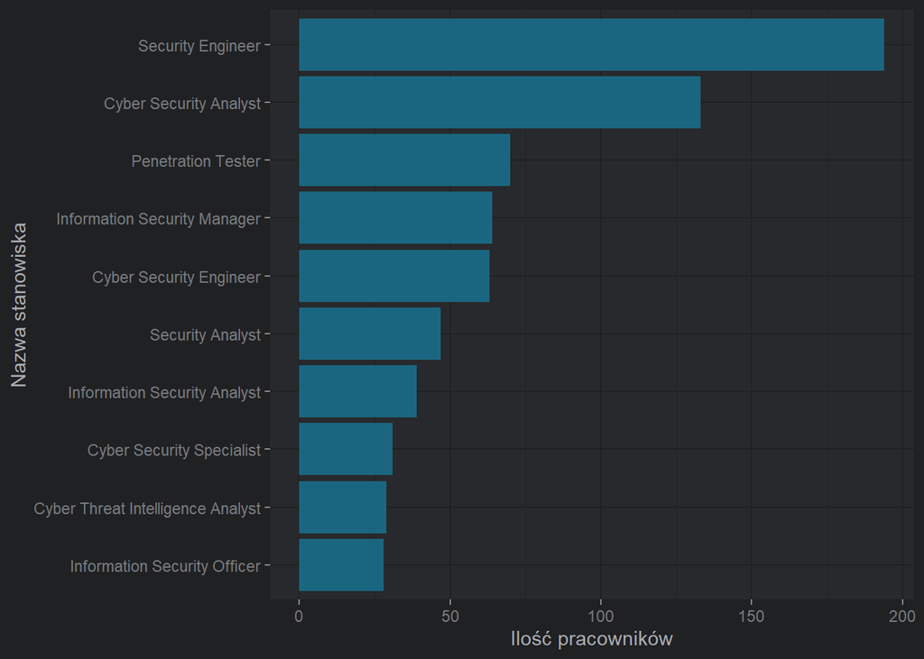

```r
most_popular_titles %>%
  mutate(job_title = fct_reorder(job_title, amount)) %>%
  ggplot(aes(x=job_title, y=amount)) +
  geom_bar(stat="identity", fill=rgb(0.1,0.4,0.5,1)) +
  coord_flip() +
  labs(x = "Nazwa stanowiska", y = "Ilość pracowników")
```

#### Wykres pudełkowy stawek pracowników zarejestrowanych w poszczególnych latach

[output not shown]

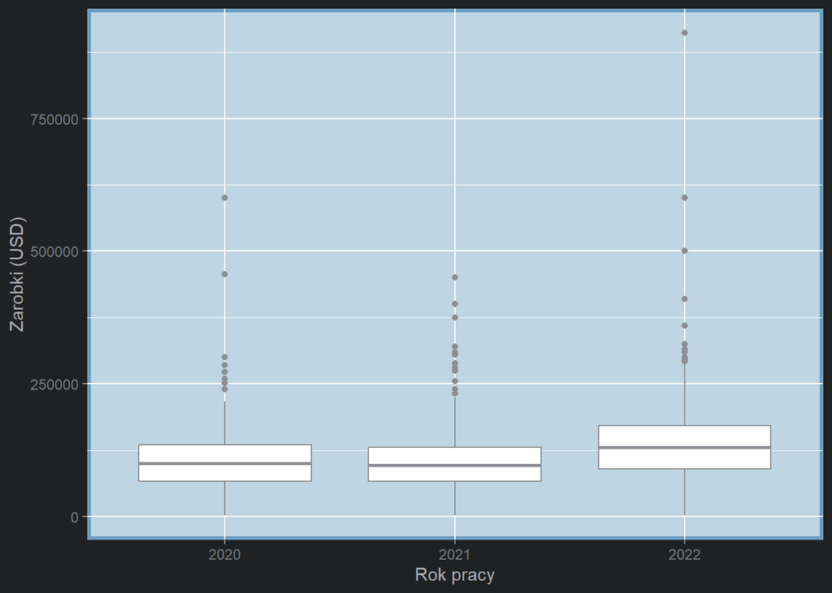

```r
ggplot(cybersecurity, aes(x=as.factor(work_year), y=salary_in_usd)) +
    geom_boxplot(fill="white", alpha=1) +
    xlab("Rok pracy") +
    ylab("Zarobki (USD)") +
    theme(
      panel.background = element_rect(fill = "#BFD5E3", colour = "#6D9EC1",
                                linewidth = 2, linetype = "solid"),
      panel.grid.major = element_line(linewidth = 0.5, linetype = 'solid',
                                colour = "white"),
     panel.grid.minor = element_line(linewidth = 0.25, linetype = 'solid',
                                colour = "white"))
```

#### Wykres pokazujący częstotliwość pracy zdalnej dla pracowników z poszczególnym stażem pracy

```r
remote_grouped = cybersecurity %>%
  group_by(experience_level, remote_ratio)%>%
  summarise(amount = n()) %>%
  group_by(experience_level) %>%
  summarise(remote_ratio, percentage = (amount/sum(amount))* 100)
remote_grouped$remote_ratio = as.character(remote_grouped$remote_ratio)

print(remote_grouped)
```

```
## # A tibble: 12 × 3
## # Groups:   experience_level [4]
##    experience_level remote_ratio percentage
##    <chr>            <chr>             <dbl>
##  1 EN               0                 20.9
##  2 EN               50                29.3
##  3 EN               100               49.8
##  4 EX               0                  6.85
##  5 EX               50                24.7
##  6 EX               100               68.5
##  7 MI               0                 24.3
##  8 MI               50                22.1
##  9 MI               100               53.6
## 10 SE               0                 15.2
## 11 SE               50                13.3
## 12 SE               100               71.5
```

[output not shown]

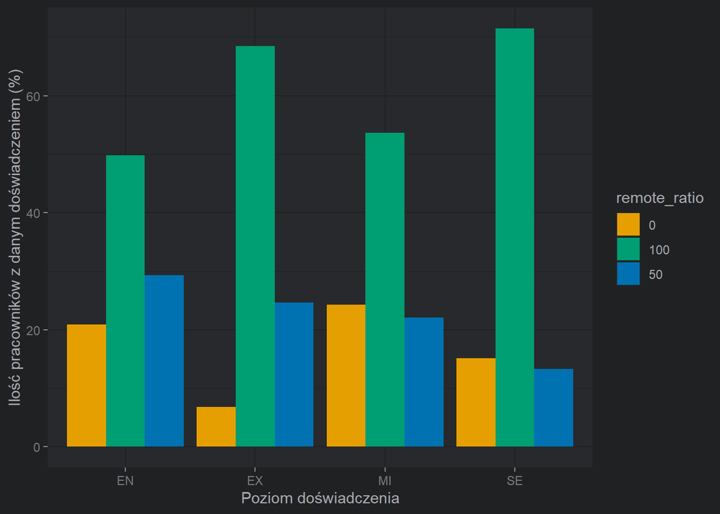

```r
ggplot(remote_grouped, aes(fill=remote_ratio, y=percentage, x=experience_level)) +
    geom_bar(position = "dodge", stat="identity") +
    xlab("Poziom doświadczenia") +
    ylab("Ilość pracowników z danym doświadczeniem (%)")
```

### Przedstawienie 10 zawodów z największą średnią wypłatą w 2022 roku

```r
jobs_grouped = cybersecurity %>%
  filter(work_year == 2022) %>%
  group_by(job_title) %>%
  summarise(avg_salary = mean(salary_in_usd)) %>%
  arrange(desc(avg_salary)) %>%
  head(10)

print(jobs_grouped)
```

```
## # A tibble: 10 × 2
##    job_title                               avg_salary
##    <chr>                                        <dbl>
##  1 Incident Response Manager                  400500
##  2 Application Security Architect             315000
##  3 Threat Intelligence Response Analyst       260000
##  4 Detection Engineer                         248358
##  5 Principal Application Security Engineer    237000
##  6 Information Security Compliance Manager    230000
##  7 Principal Security Engineer                228400
##  8 Information Security Architect             225963.
##  9 Head of Security                           194070.
## 10 Head of Information Security               192867.
```

[output not shown]

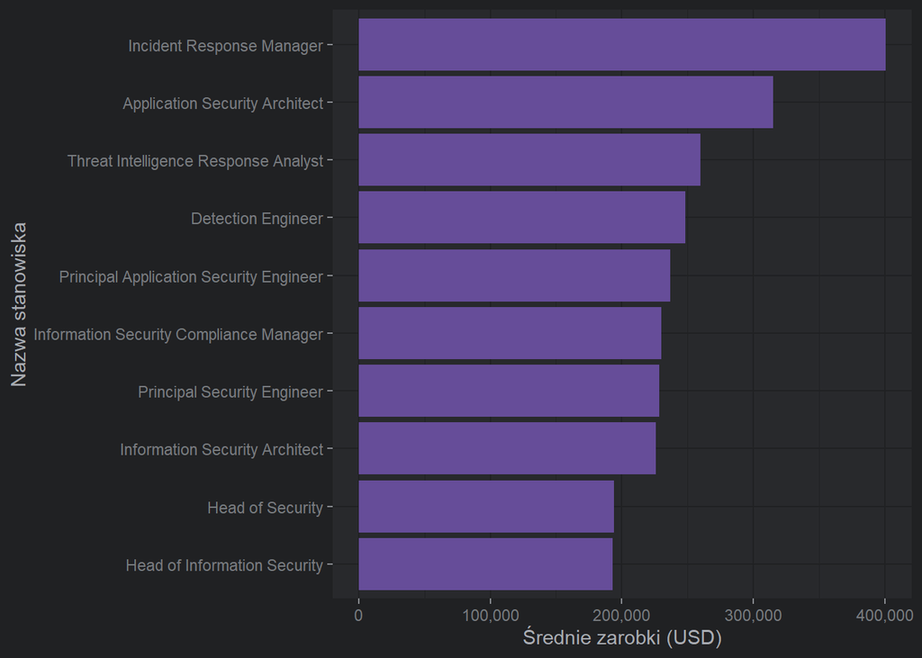

```r
jobs_grouped %>%
  mutate(job_title = fct_reorder(job_title, avg_salary)) %>%
  ggplot(aes(x=job_title, y=avg_salary)) +
  geom_bar(stat="identity", fill=rgb(0.4,0.3,0.6,1)) +
  coord_flip() +
  labs(x = "Nazwa stanowiska") +
  scale_y_continuous(name="Średnie zarobki (USD)", labels = scales::comma)
```

# Dziękujemy za uwagę

## Autorzy

Joanna Bodora, Piotr Kołodziejski